# Homework 05: Preprocessing and Cross Validation

Author

Aayush, Shubha, Tadeo

# Introduction

In this homework you will practice pre-processing data and using cross-validation to evaluate regression models.

## Learning goals

In this assignment, you will…

- Use exploratory data analysis to inform feature engineering steps
- Pre-process data and impute missing values
- Evaluate and compare models using cross-validation

# Getting Started

In last weeks homework, you learned how to share your work using GitHub and to resolve merge conflicts using branches. From here on out, you are free to use whatever version control strategy you like.

## Teams & Rules

You can find your team for this assignment on Canvas in the **People** section. The group set is called **HW5**. Your group will consist of 2-3 people and has been randomly generated. You have now been exposed to all of the Git concepts that we will talk about in this class. It is up to you to apply them to complete your homework in any way you see fit. Some rules:

1. You are all responsible for understanding the work that you turn in.
2. All team members must make roughly equal contributions to the homework.
3. Any work completed by a team member must be committed and pushed to GitHub by that person.

## Exercise 0

As in your previous homework’s, create your team on GitHub classroom and clone the repository. [Here](https://classroom.github.com/a/VhxbjrFN) is a link to the homework.

## Data: LEGO

The data for this analysis includes information about LEGO sets from themes produced January 1, 2018 and September 11, 2020. The data were originally scraped from Brickset.com, an online LEGO set guide and were obtained for this assignment from Peterson and Zieglar ([2021](https://www.tandfonline.com/doi/full/10.1080/26939169.2021.1946450)).

You will work with data on about 400 randomly selected LEGO sets produced during this time period. The primary variables are interest in this analysis are:

- `Item_Number`: a serial code corresponding to the set.
- `Set_Name`: The name of the LEGO set.
- `Theme`: Theme of the LEGO set.
- `Pieces`: Number of pieces in the set from brickset.com.
- `Amazon_Price`: Amazon price of the set scraped from brickset.com (in U.S. dollars).
- `Year` : Year the LEGO set was produced.
- `Ages`: Variable stating what aged children the set is appropriate for.
- `Pages`: Number of pages in the instruction booklet.
- `Minifigures`: Number of minifigures (LEGO people) in the set scraped from brickset.com. LEGO sets with no minifigures have been coded as NA. NA’s also represent missing data. This is due to how brickset.com reports their data.
- `Packaging`: What type of packaging the set came in.
- `Weight`: The weight of the set.
- `Unique_Pieces`: The number of unique pieces in each set.
- `Availability`: Where the set can be purchased.
- `Size`: General size of the interlocking bricks (Large = LEGO Duplo sets - which include large brick pieces safe for children ages 1 to 5, Small = LEGO sets which- include the traditional smaller brick pieces created for age groups 5 and - older, e.g., City, Friends).

Your ultimate goal will be to predict `Amazon_Price` from the other features.

# Loading & Cleaning the Data

## Libraries

All the libraries required for the completion of the homework:

```r
library(readr)
library(dplyr)
library(knitr)
library(tidyverse)
library(tidymodels)
library(caret)
library(ISLR2)
library(readODS)
library(ggrepel)

tidymodels_prefer()
```

## Exercise 1

**Question**

The data are contained in `lego-sample.csv`. Load the data.

```r
lego <- read_csv("lego-sample.csv")
head(lego)
```

```
# A tibble: 6 × 14
  Item_Number Set_Name   Theme Pieces Amazon_Price  Year Ages  Pages Minifigures
        <dbl> <chr>      <chr>  <dbl>        <dbl> <dbl> <chr> <dbl>       <dbl>
1       43172 Elsa's Ic… LEGO…    701         64.0  2019 Ages…   180           4
2       10907 World Ani… DUPLO    121         95.6  2019 Ages…    48           6
3       75278 D-O        Star…    519         57.1  2020 Ages…    72           1
4       31095 Fairgroun… Crea…    595         40    2019 Ages…   236           3
5       75976 Wrecking … Over…    227         20.0  2019 Ages…    84           1
6       41353 Friends A… Frie…    500         34    2018 Ages…     4          NA
# ℹ 5 more variables: Packaging <chr>, Weight <chr>, Unique_Pieces <dbl>,
#   Availability <chr>, Size <chr>
```

## Exercise 2

**Question**

Two of the variables in the data set shouldn’t be useful because they just serve to identify the different LEGO sets. Which two are they? Remove them.

```r
lego <- lego |> select(-Item_Number, -Set_Name)
head(lego)
```

```
# A tibble: 6 × 12
  Theme       Pieces Amazon_Price  Year Ages  Pages Minifigures Packaging Weight
  <chr>        <dbl>        <dbl> <dbl> <chr> <dbl>       <dbl> <chr>     <chr>
1 LEGO Froze…    701         64.0  2019 Ages…   180           4 <NA>      <NA>
2 DUPLO          121         95.6  2019 Ages…    48           6 Box       <NA>
3 Star Wars      519         57.1  2020 Ages…    72           1 Box       <NA>
4 Creator 3-…    595         40    2019 Ages…   236           3 Box       <NA>
5 Overwatch      227         20.0  2019 Ages…    84           1 Box       <NA>
6 Friends        500         34    2018 Ages…     4          NA Box       <NA>
# ℹ 3 more variables: Unique_Pieces <dbl>, Availability <chr>, Size <chr>
```

## Exercise 3

**Question**

Notice that the `Weight` variable is a bit odd… It seems like it should be numeric but it’s a `chr`. Why? Write code to extract the true numerical weight in either lbs or Kgs (your choice). You are encouraged to use the internet and generative AI to help you figure out how to do this. However, make sure you are able to explain your code once you are done.

```r
library(stringr)

# Extract numerical weight values in kg and rename column
lego <- lego |> mutate(
  Weight = case_when(
    str_detect(Weight, "Kg") ~ as.numeric(str_extract(Weight, "[0-9]+\\.?[0-9]*")),  # Extract Kg value
    TRUE ~ NA_real_  # Keep NA values
  )
) |> rename(`Weight (kg)` = Weight)  # Rename column

# View the cleaned dataset
print(lego)
```

```
# A tibble: 400 × 12
   Theme          Pieces Amazon_Price  Year Ages     Pages Minifigures Packaging
   <chr>           <dbl>        <dbl> <dbl> <chr>    <dbl>       <dbl> <chr>
 1 LEGO Frozen 2     701         64.0  2019 Ages_6+    180           4 <NA>
 2 DUPLO             121         95.6  2019 Ages_2+     48           6 Box
 3 Star Wars         519         57.1  2020 Ages_10+    72           1 Box
 4 Creator 3-in-1    595         40    2019 Ages_8+    236           3 Box
 5 Overwatch         227         20.0  2019 Ages_9+     84           1 Box
 6 Friends           500         34    2018 Ages_6-…     4          NA Box
 7 NINJAGO           308         63.9  2018 Ages_7-…   112           2 Box
 8 Star Wars        1177        200.   2019 Ages_8+     25          NA Box
 9 Ideas             962        154    2018 Ages_12+   156          NA Box
10 Friends           183         49.9  2018 Ages_6-…    68           1 Box
# ℹ 390 more rows
# ℹ 4 more variables: `Weight (kg)` <dbl>, Unique_Pieces <dbl>,
#   Availability <chr>, Size <chr>
```

- While looking at the dataset, we can see that while some of the weight is missing, some have weight in both kgs and lbs, with the units included, which is why it is saved as chr. I chose to keep the kg value and NA for missing values.
- **`mutate()`**: Used to modify the `Weight` column.
- **`case_when()`**: Checks different conditions and assigns appropriate values.
  - **If the weight contains “Kg”** → Extracts the number before “Kg” using `str_extract()`.
  - **If neither “Kg” nor “lb” is found** → Assigns `NA_real_` (keeps missing values as NA).
- `"[0-9]+\\.?[0-9]*"` → Extracts the first numeric value (for kg).
- **Renames the column** from `Weight` to `Weight (kg)` for clarity.

## Exercise 4

**Question**

For each of the 12 features do the following:

### Exercise 4.1

**Question**

Identify if they are the correct data type. Are categorical variables coded as factors? Are the factor levels in the correct order if necessary? Are numerical variables coded as numbers? You will need to read descriptions of the data to make this determination.

```r
glimpse(lego)
```

```
Rows: 400
Columns: 12
$ Theme         <chr> "LEGO Frozen 2", "DUPLO", "Star Wars", "Creator 3-in-1",…
$ Pieces        <dbl> 701, 121, 519, 595, 227, 500, 308, 1177, 962, 183, 827, …
$ Amazon_Price  <dbl> 63.99, 95.65, 57.09, 40.00, 19.99, 34.00, 63.93, 199.95,…
$ Year          <dbl> 2019, 2019, 2020, 2019, 2019, 2018, 2018, 2019, 2018, 20…
$ Ages          <chr> "Ages_6+", "Ages_2+", "Ages_10+", "Ages_8+", "Ages_9+", …
$ Pages         <dbl> 180, 48, 72, 236, 84, 4, 112, 25, 156, 68, 140, 112, 349…
$ Minifigures   <dbl> 4, 6, 1, 3, 1, NA, 2, NA, NA, 1, NA, 4, NA, 4, 2, 2, 4, …
$ Packaging     <chr> NA, "Box", "Box", "Box", "Box", "Box", "Box", "Box", "Bo…
$ `Weight (kg)` <dbl> NA, NA, NA, NA, NA, NA, 0.44, NA, NA, NA, 1.13, NA, NA, …
$ Unique_Pieces <dbl> 234, 75, 149, 223, 78, 202, 130, 343, 124, 105, 128, 160…
$ Availability  <chr> NA, "Retail", NA, "Retail", "Retail", "Retail", "Retail"…
$ Size          <chr> "Small", "Large", "Small", "Small", "Small", "Small", "S…
```

```r
lego <- lego |>
  mutate(Ages = factor(Ages, levels = c("Ages_2+",
                                        "Ages_6+",
                                        "Ages_8+",
                                        "Ages_9+",
                                        "Ages_10+",
                                        "Ages_6-12")))
lego <- lego |>
  mutate(Packaging = factor(Packaging),
         Availability = factor(Availability),
         Size = factor(Size, levels = c("Small",
                                        "Big")),
         Theme = factor(Theme))
```

### Exercise 4.2

**Question**

Identify any variables with missing values. Identify and then fix any variables for whom missing values (i.e. `NA`s) indicate something other than that the data is missing (there is at least one). Fill in this missing values appropriately.

```r
lego |>
  summarize(across(everything(), ~ sum(is.na(.)))) |>
  pivot_longer(everything()) |>
  filter(value > 0) |>
  kable()
```

| name | value |
| --- | --- |
| Theme | 9 |
| Ages | 222 |
| Pages | 17 |
| Minifigures | 85 |
| Packaging | 17 |
| Weight (kg) | 234 |
| Availability | 29 |
| Size | 33 |

```r
lego <- lego |>
  mutate(Minifigures = ifelse(is.na(Minifigures) & Theme %in% c("Architecture",
                                                               "DUPLO",
                                                               "LEGO Art",
                                                               "LEGO Super Mario",
                                                               "Technic"),
                                    0, Minifigures))
```

- We see that theme, ages, pages, minifigures, packages, weight, availability, and size all contain missing values. We know, from the data decription, that the NA in minifigures could represent a 0 or a missing data. To better get an idea of which data is missing and which data is actually a 0, we can consider if the lego theme historically has had minifigures in the past. We know that, generally, technic, super mario, art, duplo, and architecture sets generally do not contain minifigures.

### Exercise 4.3

**Question**

For all of the categorical variables, identify ones that you think may be problematic because they may have near-zero variance. Decide whether to remove them now, or remove them as part of your pre-processor. Make an argument for why your choice is appropriate.

```r
nearZeroVar(lego, saveMetrics = TRUE) |> kable()
```

|  | freqRatio | percentUnique | zeroVar | nzv |
| --- | --- | --- | --- | --- |
| Theme | 1.048780 | 8.00 | FALSE | FALSE |
| Pieces | 1.500000 | 76.00 | FALSE | FALSE |
| Amazon_Price | 1.090909 | 64.00 | FALSE | FALSE |
| Year | 1.045454 | 0.75 | FALSE | FALSE |
| Ages | 1.650000 | 1.50 | FALSE | FALSE |
| Pages | 1.000000 | 25.50 | FALSE | FALSE |
| Minifigures | 1.378788 | 3.50 | FALSE | FALSE |
| Packaging | 73.000000 | 2.00 | FALSE | TRUE |
| Weight (kg) | 1.500000 | 25.00 | FALSE | FALSE |
| Unique_Pieces | 1.166667 | 56.25 | FALSE | FALSE |
| Availability | 27.230769 | 0.75 | FALSE | TRUE |
| Size | 0.000000 | 0.25 | TRUE | TRUE |

```r
lego <- lego |>
  select(-Size)
```

- From the visualization above, we see that packaging, availability, and size all have near zero variance. From this, I only decided to remove size, as this column had zero variance. Additionally, although other columns had near zero variance, they could provide additional information to our model. For example in retail, lego exclusives could be more expensive than retail.

### Exercise 4.4

**Question**

For all of the categorical variables, identify ones that you think may be problematic because they have many categories that don’t have a lot of observations and likely need to be “lumped”. Decide whether to remove them now, or remove them as part of your pre-processor. Make an argument for why your choice is appropriate.

```r
lego |> count(Theme) |> kable()
```

| Theme | n |
| --- | --- |
| Architecture | 5 |
| Batman | 11 |
| BrickHeadz | 2 |
| City | 41 |
| Classic | 10 |
| Creator 3-in-1 | 17 |
| Creator Expert | 5 |
| DC | 6 |
| Disney | 20 |
| DOTS | 6 |
| DUPLO | 24 |
| Friends | 41 |
| Harry Potter | 8 |
| Hidden Side | 9 |
| Ideas | 5 |
| Juniors | 5 |
| Jurassic World | 4 |
| LEGO Art | 1 |
| LEGO Frozen 2 | 5 |
| LEGO Super Mario | 6 |
| Marvel | 20 |
| Minecraft | 13 |
| NINJAGO | 33 |
| Overwatch | 4 |
| Powerpuff Girls | 1 |
| Speed Champions | 5 |
| Spider-Man | 2 |
| Star Wars | 43 |
| Technic | 21 |
| THE LEGO MOVIE 2 | 12 |
| Trolls World Tour | 5 |
| Unikitty! | 1 |
| NA | 9 |

- We see that theme has many categories, and that some of those categories have few observations. Instead of removing this column, we could instead lump rare categories together under “other”. We could do this in the preprocessing, as this lumping would be performed for modeling purposes.

# Data Splitting & Preprocessing

## Exercise 5

**Question**

Split your data into training and test sets. Use your own judgement to determine training to test split ratio. Make sure to set a seed.

```r
set.seed(427)
lego_split <- initial_split(lego, prop = .75, strata = Amazon_Price)
lego_train <- training(lego_split)
lego_test <- testing(lego_split)
```

## Exercise 6

**Question**

Generate at least three different recipes designed to be used with linear regression that treat preprocessing differently. Hint: you’ll likely want to try out different missing value imputation or lumping strategies. It’s also a good idea to include `step_lincolm`.

```r
lm_knnimpute <- recipe(Amazon_Price ~ ., data = lego_train) |>
  step_nzv(all_predictors()) |>  # remove zero or near-zero variable predictors
  step_impute_knn(all_numeric_predictors()) |>  # impute missing values using KNN
  step_unknown(all_nominal_predictors()) |>  # handle missing categorical values
  step_other(all_nominal_predictors(), threshold = 0.01, other = "Other") |> # lump rare categories
  step_dummy(all_nominal_predictors(), one_hot = FALSE) |>  # in general use one_hot unless doing linear regression
  step_corr(all_numeric_predictors(), threshold = 0.75) |> # adjusted correlation threshold
  step_lincomb(all_numeric_predictors()) # remove variables that have exact linear combinations

lm_meanimpute <- recipe(Amazon_Price ~ ., data = lego_train) |>
  step_nzv(all_predictors()) |>  # remove zero or near-zero variable predictors
  step_impute_mean(all_numeric_predictors()) |>  # impute missing values using mean
  step_unknown(all_nominal_predictors()) |>  # handle missing categorical values
  step_other(all_nominal_predictors(), threshold = 0.01, other = "Other") |> # lump rare categories
  step_dummy(all_nominal_predictors(), one_hot = FALSE) |>  # in general use one_hot unless doing linear regression
  step_corr(all_numeric_predictors(), threshold = 0.75) |> # adjusted correlation threshold
  step_lincomb(all_numeric_predictors()) # remove variables that have exact linear combinations

lm_medianimpute <- recipe(Amazon_Price ~ ., data = lego_train) |>
  step_nzv(all_predictors()) |>  # remove zero or near-zero variable predictors
  step_impute_median(all_numeric_predictors()) |>  # impute missing values using median
  step_unknown(all_nominal_predictors()) |>  # handle missing categorical values
  step_other(all_nominal_predictors(), threshold = 0.01, other = "Other") |> # lump rare categories
  step_dummy(all_nominal_predictors(), one_hot = FALSE) |>  # in general use one_hot unless doing linear regression
  step_corr(all_numeric_predictors(), threshold = 0.75) |> # adjusted correlation threshold
  step_lincomb(all_numeric_predictors()) # remove variables that have exact linear combinations
```

## Exercise 7

**Question**

Generate at least three different recipes designed to be used with $K$-nearest neighbors that treat preprocessing differently. Hint: you’ll likely want to try out different missing value imputation or lumping strategies.

```r
knn_preproc1 <- recipe(Amazon_Price ~ ., data = lego_train) |>
  step_nzv(all_predictors()) |>  # remove zero or near-zero variable predictors
  step_impute_knn(all_numeric_predictors()) |>  # impute missing values using KNN
  step_unknown(all_nominal_predictors()) |>  # handle missing categorical values
  step_other(all_nominal_predictors(), threshold = 0.01, other = "Other") |> # lump rare categories
  step_dummy(all_nominal_predictors(), one_hot = TRUE) |>  # one-hot encode categorical variables
  step_corr(all_numeric_predictors(), threshold = 0.75) |> # adjusted correlation threshold
  step_lincomb(all_numeric_predictors()) |> # remove linear combinations
  step_normalize(all_numeric_predictors()) # normalize numeric predictors

knn_preproc2 <- recipe(Amazon_Price ~ ., data = lego_train) |>
  step_nzv(all_predictors()) |>  # remove zero or near-zero variable predictors
  step_impute_mean(all_numeric_predictors()) |>  # impute missing values using mean
  step_unknown(all_nominal_predictors()) |>  # handle missing categorical values
  step_other(all_nominal_predictors(), threshold = 0.01, other = "Other") |> # lump rare categories
  step_dummy(all_nominal_predictors(), one_hot = TRUE) |>  # one-hot encode categorical variables
  step_corr(all_numeric_predictors(), threshold = 0.75) |> # adjusted correlation threshold
  step_lincomb(all_numeric_predictors()) |> # remove linear combinations
  step_normalize(all_numeric_predictors()) # normalize numeric predictors

knn_preproc3 <- recipe(Amazon_Price ~ ., data = lego_train) |>
  step_nzv(all_predictors()) |>  # remove zero or near-zero variable predictors
  step_impute_median(all_numeric_predictors()) |>  # impute missing values using median
  step_unknown(all_nominal_predictors()) |>  # handle missing categorical values
  step_other(all_nominal_predictors(), threshold = 0.01, other = "Other") |> # lump rare categories
  step_dummy(all_nominal_predictors(), one_hot = TRUE) |>  # one-hot encode categorical variables
  step_corr(all_numeric_predictors(), threshold = 0.75) |> # adjusted correlation threshold
  step_lincomb(all_numeric_predictors()) |> # remove linear combinations
  step_normalize(all_numeric_predictors()) # normalize numeric predictors
```

# Model-Fitting & Evaluation

## Exercise 7

**Question**

Create a `workflow_set` that contains 12 different workflows:

- three linear regression workflows: one linear regression model with each of the three recipes you created above
- nine different KNN workflows: choose three different $K$s for you KNN models and create one workflow for each combination of KNN model and preprocessing recipe

```r
# Linear regression model
lm_model <- linear_reg() |> set_engine("lm")

# KNN models with different K values
knn5_model <- nearest_neighbor(mode = "regression", neighbors = 5) |> set_engine("kknn")
knn10_model <- nearest_neighbor(mode = "regression", neighbors = 10) |> set_engine("kknn")
knn15_model <- nearest_neighbor(mode = "regression", neighbors = 15) |> set_engine("kknn")

# Define preprocessing strategies for KNN
knn_preprocessors <- list(
  knn_knn_impute = knn_preproc1,
  knn_mean_impute = knn_preproc2,
  knn_median_impute = knn_preproc3
)

# Define preprocessing strategies for Linear Regression
lm_preprocessors <- list(
  lm_knn_impute = lm_knnimpute,
  lm_mean_impute = lm_meanimpute,
  lm_median_impute = lm_medianimpute
)

# Associate models with preprocessing strategies
knn_models <- list(
  knn5 = knn5_model,
  knn10 = knn10_model,
  knn15 = knn15_model
)

lm_models <- list(
  lm_model = lm_model
)

# Create workflow sets
knn_workflows <- workflow_set(knn_preprocessors, knn_models, cross = TRUE)
lm_workflows <- workflow_set(lm_preprocessors, lm_models, cross = TRUE)

# Combine workflows
all_models <- bind_rows(lm_workflows, knn_workflows)

print(all_models)  # Check workflows
```

```
# A workflow set/tibble: 12 × 4
   wflow_id                  info             option    result
   <chr>                     <list>           <list>    <list>
 1 lm_knn_impute_lm_model    <tibble [1 × 4]> <opts[0]> <list [0]>
 2 lm_mean_impute_lm_model   <tibble [1 × 4]> <opts[0]> <list [0]>
 3 lm_median_impute_lm_model <tibble [1 × 4]> <opts[0]> <list [0]>
 4 knn_knn_impute_knn5       <tibble [1 × 4]> <opts[0]> <list [0]>
 5 knn_knn_impute_knn10      <tibble [1 × 4]> <opts[0]> <list [0]>
 6 knn_knn_impute_knn15      <tibble [1 × 4]> <opts[0]> <list [0]>
 7 knn_mean_impute_knn5      <tibble [1 × 4]> <opts[0]> <list [0]>
 8 knn_mean_impute_knn10     <tibble [1 × 4]> <opts[0]> <list [0]>
 9 knn_mean_impute_knn15     <tibble [1 × 4]> <opts[0]> <list [0]>
10 knn_median_impute_knn5    <tibble [1 × 4]> <opts[0]> <list [0]>
11 knn_median_impute_knn10   <tibble [1 × 4]> <opts[0]> <list [0]>
12 knn_median_impute_knn15   <tibble [1 × 4]> <opts[0]> <list [0]>
```

## Exercise 8

**Question**

Use 5 fold CV with 5 repeats to compute the RMSE and R-squared for each of the 12 workflows you created above. Note that this step may take a few minutes to execute.

```r
# Define metrics
lego_metrics <- metric_set(rmse, rsq)

# Define 5-fold CV with 5 repeats
lego_folds <- vfold_cv(lego_train, v = 5, repeats = 5)

# Fit resamples for all models
all_fits <- all_models |>
  workflow_map("fit_resamples",
               resamples = lego_folds,
               metrics = lego_metrics)

# Collect and display RMSE results
collect_metrics(all_fits) |>
  filter(.metric == "rmse") |>
  kable()
```

| wflow_id | .config | preproc | model | .metric | .estimator | mean | n | std_err |
| --- | --- | --- | --- | --- | --- | --- | --- | --- |
| lm_knn_impute_lm_model | Preprocessor1_Model1 | recipe | linear_reg | rmse | standard | 30.39880 | 25 | 1.760440 |
| lm_mean_impute_lm_model | Preprocessor1_Model1 | recipe | linear_reg | rmse | standard | 32.26788 | 25 | 1.807816 |
| lm_median_impute_lm_model | Preprocessor1_Model1 | recipe | linear_reg | rmse | standard | 31.64320 | 25 | 1.716108 |
| knn_knn_impute_knn5 | Preprocessor1_Model1 | recipe | nearest_neighbor | rmse | standard | 37.42914 | 25 | 1.557669 |
| knn_knn_impute_knn10 | Preprocessor1_Model1 | recipe | nearest_neighbor | rmse | standard | 38.19662 | 25 | 1.670968 |
| knn_knn_impute_knn15 | Preprocessor1_Model1 | recipe | nearest_neighbor | rmse | standard | 38.90586 | 25 | 1.709972 |
| knn_mean_impute_knn5 | Preprocessor1_Model1 | recipe | nearest_neighbor | rmse | standard | 38.07992 | 25 | 1.268635 |
| knn_mean_impute_knn10 | Preprocessor1_Model1 | recipe | nearest_neighbor | rmse | standard | 38.10749 | 25 | 1.281523 |
| knn_mean_impute_knn15 | Preprocessor1_Model1 | recipe | nearest_neighbor | rmse | standard | 38.59597 | 25 | 1.330035 |
| knn_median_impute_knn5 | Preprocessor1_Model1 | recipe | nearest_neighbor | rmse | standard | 38.33044 | 25 | 1.342746 |
| knn_median_impute_knn10 | Preprocessor1_Model1 | recipe | nearest_neighbor | rmse | standard | 38.25537 | 25 | 1.339362 |
| knn_median_impute_knn15 | Preprocessor1_Model1 | recipe | nearest_neighbor | rmse | standard | 38.62313 | 25 | 1.397009 |

```r
# Collect and display R-squared results
collect_metrics(all_fits) |>
  filter(.metric == "rsq") |>
  kable()
```

| wflow_id | .config | preproc | model | .metric | .estimator | mean | n | std_err |
| --- | --- | --- | --- | --- | --- | --- | --- | --- |
| lm_knn_impute_lm_model | Preprocessor1_Model1 | recipe | linear_reg | rsq | standard | 0.6679599 | 25 | 0.0228479 |
| lm_mean_impute_lm_model | Preprocessor1_Model1 | recipe | linear_reg | rsq | standard | 0.6414735 | 25 | 0.0239907 |
| lm_median_impute_lm_model | Preprocessor1_Model1 | recipe | linear_reg | rsq | standard | 0.6493019 | 25 | 0.0212430 |
| knn_knn_impute_knn5 | Preprocessor1_Model1 | recipe | nearest_neighbor | rsq | standard | 0.4710715 | 25 | 0.0264183 |
| knn_knn_impute_knn10 | Preprocessor1_Model1 | recipe | nearest_neighbor | rsq | standard | 0.4719900 | 25 | 0.0256976 |
| knn_knn_impute_knn15 | Preprocessor1_Model1 | recipe | nearest_neighbor | rsq | standard | 0.4731863 | 25 | 0.0245884 |
| knn_mean_impute_knn5 | Preprocessor1_Model1 | recipe | nearest_neighbor | rsq | standard | 0.4426374 | 25 | 0.0344936 |
| knn_mean_impute_knn10 | Preprocessor1_Model1 | recipe | nearest_neighbor | rsq | standard | 0.4619793 | 25 | 0.0319765 |
| knn_mean_impute_knn15 | Preprocessor1_Model1 | recipe | nearest_neighbor | rsq | standard | 0.4685257 | 25 | 0.0322671 |
| knn_median_impute_knn5 | Preprocessor1_Model1 | recipe | nearest_neighbor | rsq | standard | 0.4386825 | 25 | 0.0340399 |
| knn_median_impute_knn10 | Preprocessor1_Model1 | recipe | nearest_neighbor | rsq | standard | 0.4606405 | 25 | 0.0299335 |
| knn_median_impute_knn15 | Preprocessor1_Model1 | recipe | nearest_neighbor | rsq | standard | 0.4714497 | 25 | 0.0297813 |

## Exercise 9

**Question**

Plot the results of your cross validation and select your best workflow.

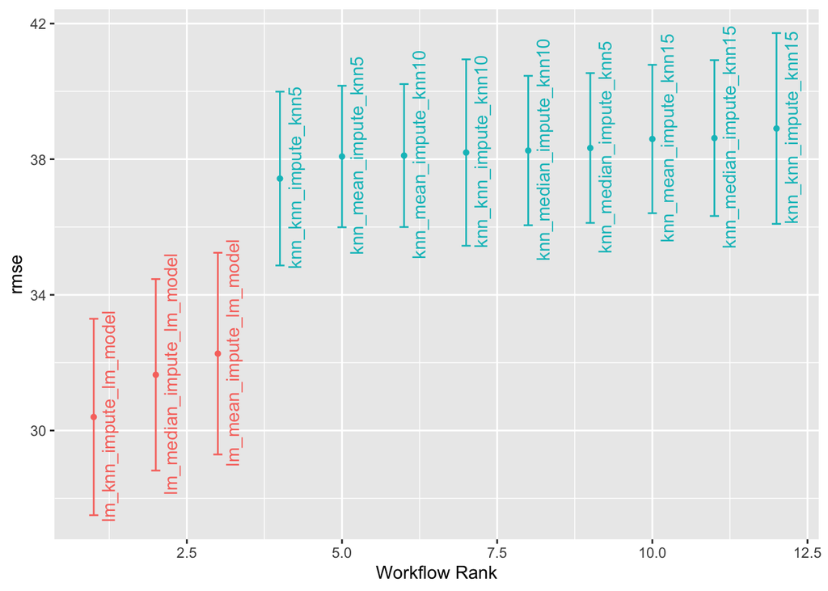

```r
autoplot(all_fits, metric = "rmse") +
  geom_text_repel(aes(label = wflow_id), nudge_x = 1/8, nudge_y = 1/100, angle = 90) +
  theme(legend.position = "none")
```

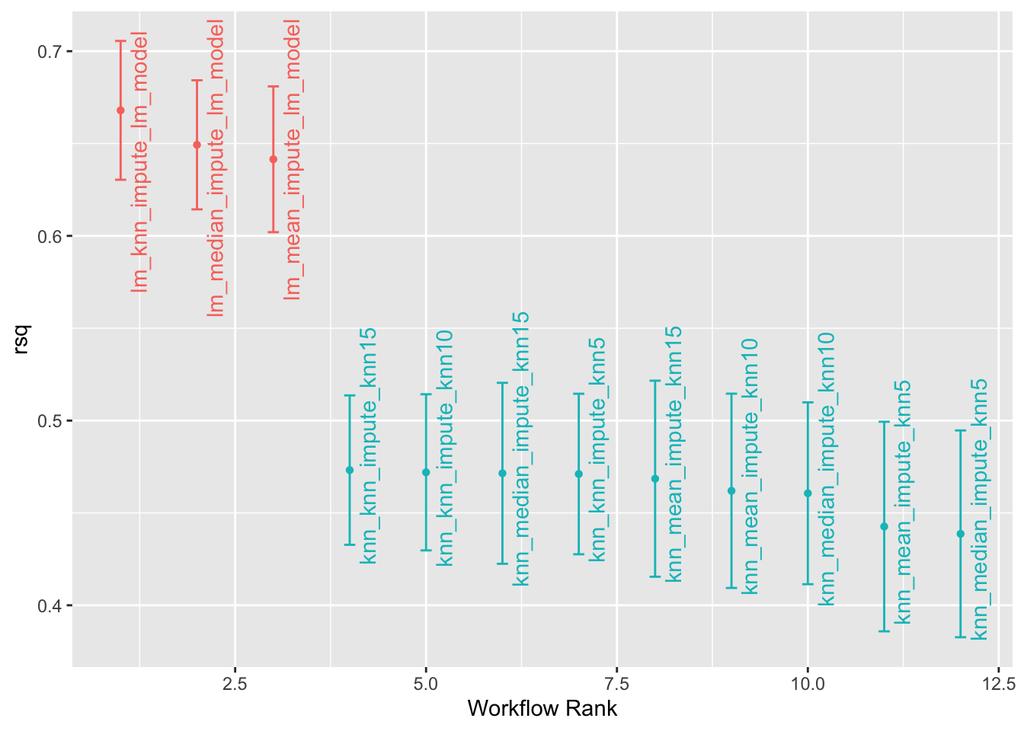

```r
autoplot(all_fits, metric = "rsq") +
  geom_text_repel(aes(label = wflow_id), nudge_x = 1/8, nudge_y = 1/100, angle = 90) +
  theme(legend.position = "none")
```

As we know, higher $R^2$ values and lower RMSE values are better.

As we can clearly see in the graph, lm models are clearly better than the KNN models. In the first graph lm models have the lowest RMSE values and in the second graph we have the highest $R^2$ values. Therefore linear model are better performers than LNN model in this scenario.

To be specific we observed that **lm_knn_impute_lm_model** to show the best performance out of all.

## Exercise 10

**Question**

Re-fit your best model on the whole training set and estimate your error metrics on the test set.

```r
best_workflow <- all_models |>
  extract_workflow("lm_knn_impute_lm_model")

final_fit <- best_workflow |>
  fit(data = lego_train)

final_predict <- final_fit |>
  predict(new_data = lego_test) |>
  bind_cols(lego_test)

test_metrics <- final_predict |>
  metrics(truth = Amazon_Price, estimate = .pred)

test_metrics |> kable()
```

| .metric | .estimator | .estimate |
| --- | --- | --- |
| rmse | standard | 62.4210635 |
| rsq | standard | 0.5755068 |
| mae | standard | 29.7575259 |

# Conceptual Question

## Exercise 11 (Sample interview question)

**Question**

The time to complete cross-validation can be substantially improved by using parallel processing. Below is the output for the copilot prompt “Generate pseudo-code in R to do cross-validation with repetition and multiple models”. Which parts of this code can be run in parallel and which can’t. Note any changes that you might need to make for this to be parallelizable.

```r
# Define the number of folds (k) and the number of repetitions (r)
k <- 5
r <- 3

# Define the list of models to evaluate
models <- list(
    model1 = train_model1,
    model2 = train_model2,
    model3 = train_model3
)

# Initialize a list to store the performance metrics for each model
all_performance_metrics <- list()

# Loop through each model
for (model_name in names(models)) {
    # Initialize a list to store the performance metrics for this model
    model_performance_metrics <- list()

    # Loop through each repetition
    for (rep in 1:r) {
        # Create k-fold cross-validation indices for this repetition
        folds <- createFolds(dataset$target_variable, k = k)

        # Initialize a list to store the performance metrics for this repetition
        performance_metrics <- list()

        # Loop through each fold
        for (i in 1:k) {
            # Use the i-th fold as the validation set
            validation_indices <- folds[[i]]
            validation_set <- dataset[validation_indices, ]

            # Use the remaining folds as the training set
            training_set <- dataset[-validation_indices, ]

            # Train the model on the training set
            model <- models[[model_name]](training_set)

            # Evaluate the model on the validation set
            performance <- evaluate_model(model, validation_set)

            # Store the performance metric
            performance_metrics[[i]] <- performance
        }

        # Store the performance metrics for this repetition
        model_performance_metrics[[rep]] <- performance_metrics
    }

    # Store the performance metrics for this model
    all_performance_metrics[[model_name]] <- model_performance_metrics
}

# Calculate the average performance metric for each model across all repetitions
average_performance <- sapply(all_performance_metrics, function(metrics) mean(unlist(metrics)))

# Output the average performance for each model
print("Average Performance for each model:")
print(average_performance)
```